# L3 - Data Tables & Subsetting

## Reshaping Data

- Split/combine variables w/ `separate()/unite()`

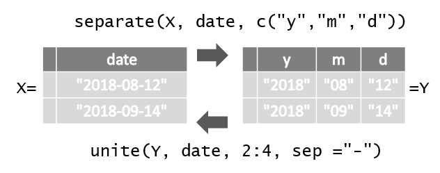

- Sort data w/ `arrange()`

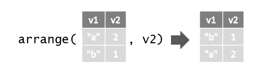

## Pipes

- Pipe operator `%>%` passes object on its left as (first) argument of function to its right
  - `x %>% f(y) = f(x, y)`
- Apply functions *sequentially*  
  `data %>% filter( ) %>% select( ) %>% arrange( )`

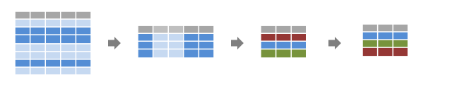

  - Identical but much *easier to read* than  
    `arrange( select( filter(data) ) ) )`

## Dinesafe Data

- Toronto [Dinesafe](https://www.toronto.ca/health/dinesafe/system.htm) program
  - Every food-serving establishment receives 1-3+ inspections/year
  - Public Health Inspector assigns one of 3 types of notice:

[figure not shown]

- Available through City of Toronto's [Open Data](https://www.toronto.ca/city-government/data-research-maps/open-data/open-data-catalogue/health/#e3c15b0f-5f83-0f12-fabb-c84018395c38)

## Dinesafe Data

- Data Variables

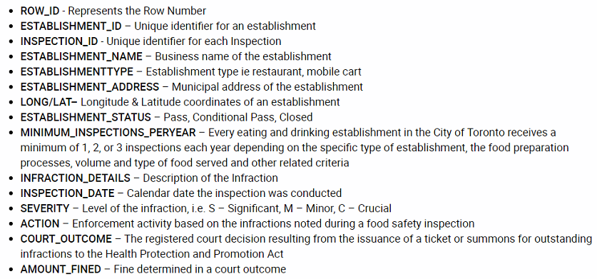

## Dinesafe Data

```r
glimpse(dinesafe)
## Observations: 90,520
## Variables: 16
## $ ROW_ID                      <int> 1, 2, 3, 4, 5, 6, 7, 8, 9, 10, 11,...
## $ ESTABLISHMENT_ID            <int> 1222579, 1222579, 1222579, 1222579...
## $ INSPECTION_ID               <int> 103868579, 104063869, 104246429, 1...
## $ ESTABLISHMENT_NAME          <chr> "SAI-LILA KHAMAN DHOKLA HOUSE", "S...
## $ ESTABLISHMENTTYPE           <chr> "Food Take Out", "Food Take Out", ...
## $ ESTABLISHMENT_ADDRESS       <chr> "870 MARKHAM RD", "870 MARKHAM RD"...
## $ LATITUDE                    <dbl> 43.76798, 43.76798, 43.76798, 43.7...
## $ LONGITUDE                   <dbl> -79.22903, -79.22903, -79.22903, -...
## $ ESTABLISHMENT_STATUS        <chr> "Pass", "Pass", "Pass", "Pass", "P...
## $ MINIMUM_INSPECTIONS_PERYEAR <int> 2, 2, 2, 2, 2, 2, 2, 2, 2, 2, 2, 2...
## $ INFRACTION_DETAILS          <chr> "Operator fail to properly wash eq...
## $ INSPECTION_DATE             <date> 2016-12-21, 2017-10-04, 2018-06-2...
## $ SEVERITY                    <chr> "M - Minor", NA, "NA - Not Applica...
## $ ACTION                      <chr> "Notice to Comply", NA, "Notice to...
## $ COURT_OUTCOME               <chr> NA, NA, NA, NA, NA, NA, NA, NA, NA...
## $ AMOUNT_FINED                <dbl> NA, NA, NA, NA, NA, NA, NA, NA, NA...
```

## Dinesafe Data

- Lets explore the data using what we learned!